# Improving the workflow to crack Small, Unbalanced, Noisy, but Genuine (SUNG) datasets in bioacoustics: the case of bonobo calls

Discriminant Analysis (DFA) with Principal Component Analysis (PCA) to work with MFCC as predictors

Vincent Arnaud[^1], François Pellegrino[^2], Sumir Keenan[^3], Xavier St-Gelais[^4], Nicolas Mathevon[^5], Florence Levréro[^6], Christophe Coupé[^7]

Last update: 14 mars, 2023

# 1 Preparatory steps for the Markdown file

Setting the options for *knitr*…

```r
library(knitr)
knitr::opts_chunk$set(results = 'asis',
                       echo = TRUE,
                       comment = NA,
                       prompt = FALSE,
                       cache = FALSE,
                       warning = FALSE,
                       message = FALSE,
                       fig.align = "center",
                       fig.width = 8.125,
                       out.width = "100%",
                       fig.path = "Figures/figures_dfa/",
                       dev = c('png', 'tiff'),
                       dev.args = list(png = list(type = "cairo"), tiff = list(compression = 'lzw')),
                       cache = TRUE,
                       cache.path = "D:/cache/cache_dfa/",
                       autodep = TRUE)
options(width = 1000, scipen = 999, knitr.kable.NA = '')
```

Loading libraries…

```r
library(dplyr)
library(purrr)
library(forcats)
library(MASS)
library(ggplot2)
library(caret)
library(kableExtra)
library(pROC)
library(ggrepel)
library(GGally)
library(splitstackshape)
library(fmsb)
library(tidyr)
```

# 2 Loading R objects previously defined

We load data tables and definitions of features sets prepared during the curation phase…

```r
load(file = "Study_objects.RData")
```

# 3 Defining the key variables

Defining the predicted variables (**individual, type…**)…

```r
DVs <- c("individual", "type")
```

# 4 Choosing the feature set

We work here only with MFCC…

```r
set_names <- "MFCC"
```

We create a (named) list of this set. We only consider the first 96 coefficients, i.e., we discard the standard deviations for the coefficients…

```r
SETs <- list(MFCC_set[1:96])
```

We perform the PCA and add the transformed coordinates of the observations (along the principal components) to the main data table…

```r
df.pca <- df %>% dplyr::select(all_of(SETs[[1]]))

MFCC_pca <- prcomp(df.pca, center = F, scale = F)

MFCC_set <- colnames(MFCC_pca$x)
df <- cbind(df, MFCC_pca$x)
```

We update our SETs object with the reduced PCA-MFCC set…

```r
SETs <- list(MFCC_set)
```

# 5 PCA optimization

```r
n.sel <- 100 # Number of iterations
n.pc <- length(SETs[[1]])

# We initialize a number of objects to store data
CONTROL <- NULL
class2 <- list()


# We iterate over our different DV
for (DV in DVs) {

  # We define the CONTROL variable
  if (DV == "type") {
    CONTROL <- "individual"
  }

  if (DV == "individual") {
    CONTROL <- "type"
  }

# We iterate over the number of PC
  for (z in 1:n.pc) {

      # We initialize objects
      class <- list()
      confusion <- list()

      # We collapse the names of the variable in order to build a formula for our model
      SET2 <- paste(SETs[[1]][1:z], collapse = "+")

      # We build object for the set under study
      SET <- c(SETs[[1]][1:z], DV)
      set_name <- set_names[1]

    # Number of levels of the dependent variable
    ntf.levels <- length(unique(df[[DV]]))

    # We compute 2/3 of the smallest number of observations we can find in one of the levels of the DV
    n.to.sel <- df %>%
      group_by_at(DV) %>%
      summarise(n = n() ) %>%
      slice_min(n, with_ties = FALSE) %>%
      pull() %>%
      {round((3/4)*., digits=0)}

      # We create a subset of our main data table which contains only the explanatory variable of the set under study, the DV and the control variable
      df.set <- df %>%
        dplyr::select(all_of(SET), all_of(DV), all_of(CONTROL)) %>%
        tibble::rownames_to_column(., var = "rowname")

      for (k in 1:n.sel) {
        set.seed(k)  # Set the random seed for reproducibility

        # We make a random partition of df.set so that we pick n.to.sel elements in each level of the factor DV to assemble a training set
        # The test set is made of the remaining elements
        samples <- stratified(df.set, DV, size = n.to.sel, bothSets = T)

        # Training set
        training <- samples$SAMP1
        training.class <- training %>% pull(all_of(DV))
        training.data <- training %>% dplyr::select(all_of(SETs[[1]][1:z]))

        training.prior <- training %>%
          count(get(DV)) %>%
          mutate(prop = prop.table(n)) %>%
          pull() %>%
          as.numeric()

        # Test set
        testing <- samples$SAMP2
        testing.class <- testing %>% pull(all_of(DV))
        testing.data <- testing %>% dplyr::select(all_of(SETs[[1]][1:z]))

        testing.prior <- testing %>%
          count(get(DV)) %>%
          mutate(prop = prop.table(n)) %>%
          pull() %>%
          as.numeric()

        # we define the DFA model with the training set
        model <- paste("lda(", DV, "~", SET2,", prior=training.prior, data=training)", sep="")
        # we compute the model and store the outputs in 'res'
        res <- eval(parse(text=model))

        training.pred <- predict(res)
        training$pred <- training.pred$class

        # We apply the model to the test set
        testing.pred <- predict(res, testing.data, prior=testing.prior)
        testing$pred <- testing.pred$class

        # We compute the negative of the multinomial log-likelihood (smaller is better)
        mnlogloss <- testing %>%
          mutate(observed=as.factor(get(DV))) %>%
          dplyr::select(observed) %>%
          bind_cols(testing.pred$posterior) %>%
          mnLogLoss(., lev = levels(.$observed)) %>% as.numeric()

        # We create the confusion matrix for the current iteration
        confusion[[k]] <- table(list(predicted=testing$pred, observed=testing[[DV]]))

        # We extract the values of a few metrics
        acc <- t(confusionMatrix(confusion[[k]])$overall[[1]])
        #acc <- mean(confusionMatrix(confusion[[k]])[["byClass"]][,11])
        auc <- multiclass.roc(response = testing[[DV]], predictor=testing.pred$posterior)$auc[1]

        # The balanced accuracy in binary and multiclass classification problems is another option to address
        # imbalanced datasets. It is defined as the average of recall obtained on each class.
        # https://scikit-learn.org/stable/modules/generated/sklearn.metrics.balanced_accuracy_score.html

        bal <- mean(confusionMatrix(confusion[[k]])[["byClass"]][,1])

        # We create and store a data frame for the current iteration
        # We save the number of correct classifications and percentage of correct classification for both training and test sets
        # and also the different metrics for the test set
        class[[k]] <- data.frame(DV, z, k,
                                 n.training=nrow(training),
                                 n.testing=nrow(testing),
                                 mnlogloss, auc, acc, bal)
      }

      # We bind the clasification data for all the iterations
      class2[[DV]][[z]] <- do.call("rbind", class)
  }

}
```

```r
data <- purrr::map(class2, ~ bind_rows(.x)) %>%
  bind_rows() %>%
  group_by(DV, z)
```

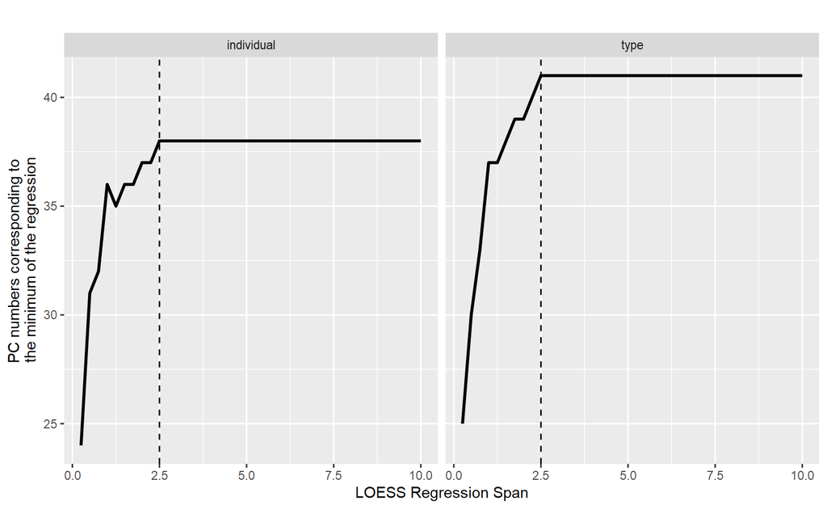

```r
attempts <- list()
span_values <- seq(0.25, 10, 0.25)

for (i in 1:length(span_values)) {
  attempts[[i]] <- data %>%
    group_by(DV) %>%
    nest() %>%
          dplyr::mutate(
                  # Perform loess calculation on each DV group
                  m = purrr::map(data, loess,
                                 formula = mnlogloss~z , span = span_values[i]),
                  # Retrieve the predicted values from each model
                  fitted = predict(m, newdata=c(1: 96))
          ) %>%
          dplyr::select(-m, -data) %>%
          tidyr::unnest(cols = c(fitted))  %>%
    group_by(DV) %>%
    mutate(z = row_number()) %>%
    slice_min(fitted)  %>%
    mutate(span = span_values[i]) %>%
    ungroup()
}

attempts %>%
  bind_rows() %>%
  group_by(DV) %>%
  ggplot(., aes(x=span, y=z)) +
  geom_line(linewidth = 1) +
  geom_vline(aes(xintercept=2.5), linetype="dashed") +
  facet_grid(~DV) +
  labs(title="", y ="PC numbers corresponding to\n the minimum of the regression", x = "LOESS Regression Span")
```

We select 2.5 as the optimal value for span for both individual and type, as a larger value doesn’t change the number of components

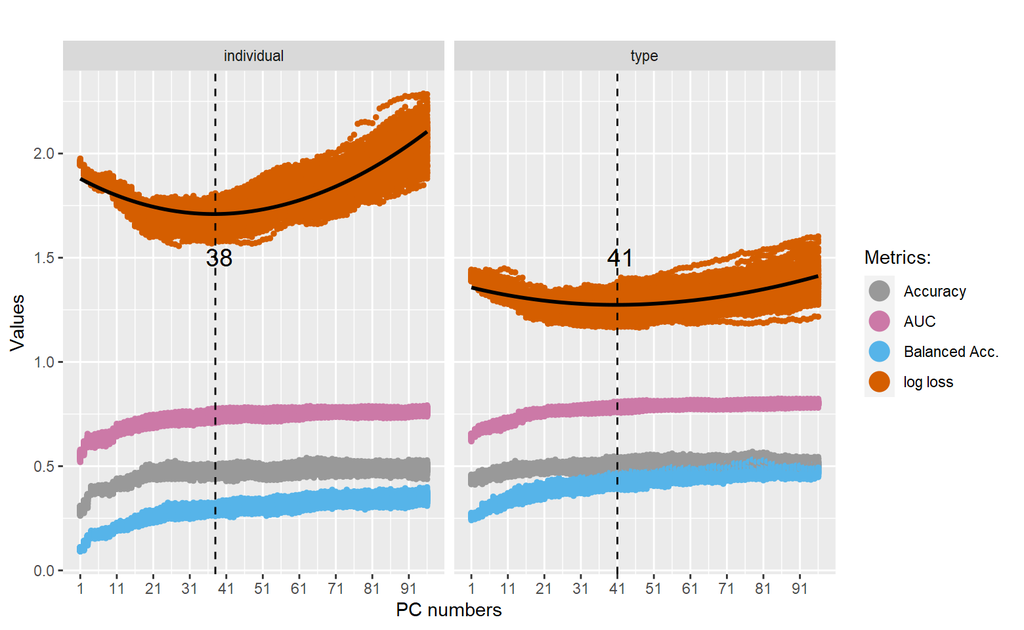

```r
span <- 2.5

min.loess <- data %>%
  group_by(DV) %>%
  nest() %>%
        dplyr::mutate(
                # Perform loess calculation on each DV group
                m = purrr::map(data, loess,
                               formula = mnlogloss~z , span = span),
                # Retrieve the predicted values from each model
                fitted = predict(m, newdata=c(1: 96))
        ) %>%
        dplyr::select(-m, -data) %>%
        tidyr::unnest(cols = c(fitted))  %>%
  group_by(DV) %>%
  mutate(z = row_number()) %>%
  slice_min(fitted)


data %>%
  pivot_longer(mnlogloss:bal, names_to = "metric") %>%
  mutate(alpha = case_when(metric == "mnlogloss" ~ 1,
    TRUE ~ 0
    )) %>%
  ggplot(.) +
  geom_point(aes(z, value, color= metric), size=1) +
  scale_x_continuous(breaks=seq(1, 96, 10)) +
  geom_line(stat="smooth",method = "loess", span = span, aes(z, value, group= metric, alpha = alpha),
              linewidth = 1, color="black") +
  scale_alpha_continuous(range = c(0, 1), guide = "none") +
  facet_grid(~DV) +
  labs(title="", y ="Values", x = "PC numbers", color='Metrics:') +
  geom_vline(data=min.loess, aes(xintercept=z), linetype="dashed") +
  geom_text(data=min.loess, aes(z+1, mnlogloss+0.2, label=z), size=5) +
  scale_color_manual(labels = c("Accuracy", "AUC", "Balanced Acc.", "log loss"), values=c("#999999", "#CC79A7", "#56B4E9", "#D55E00") ) +
  guides(color = guide_legend(override.aes = list(size=5)))
```

We find that 38 and 41 are optimal numbers of dimensions for individuals and types, respectively. For the sake of simplicity, we note down these optimal values and will provide them in the second piece of code to compute the performances of the DFA with MFCC.

# 6 Environment

R version 4.1.3 (2022-03-10)  
Platform: x86_64-w64-mingw32/x64 (64-bit)  
OS version: Windows 10 x64 (build 22000)

# 7 Packages

`stats`: *The R Stats Package* version 4.1.3  
`graphics`: *The R Graphics Package* version 4.1.3  
`grDevices`: *The R Graphics Devices and Support for Colours and Fonts* version 4.1.3  
`utils`: *The R Utils Package* version 4.1.3  
`datasets`: *The R Datasets Package* version 4.1.3  
`methods`: *Formal Methods and Classes* version 4.1.3  
`base`: *The R Base Package* version 4.1.3  
`tidyr`: *Tidy Messy Data* version 1.2.1  
`fmsb`: *Functions for Medical Statistics Book with some Demographic Data* version 0.7.3  
`splitstackshape`: *Stack and Reshape Datasets After Splitting Concatenated Values* version 1.4.8  
`GGally`: *Extension to ‘ggplot2’* version 2.1.2  
`ggrepel`: *Automatically Position Non-Overlapping Text Labels with ‘ggplot2’* version 0.9.2  
`pROC`: *Display and Analyze ROC Curves* version 1.18.0  
`kableExtra`: *Construct Complex Table with ‘kable’ and Pipe Syntax* version 1.3.4  
`caret`: *Classification and Regression Training* version 6.0-93  
`lattice`: *Trellis Graphics for R* version 0.20-45  
`ggplot2`: *Create Elegant Data Visualisations Using the Grammar of Graphics* version 3.4.0  
`MASS`: *Support Functions and Datasets for Venables and Ripley’s MASS* version 7.3-55  
`forcats`: *Tools for Working with Categorical Variables (Factors)* version 0.5.2  
`purrr`: *Functional Programming Tools* version 0.3.4  
`dplyr`: *A Grammar of Data Manipulation* version 1.0.10  
`knitr`: *A General-Purpose Package for Dynamic Report Generation in R* version 1.41

[^1]: Département des arts, des lettres et du langage, Université du Québec à Chicoutimi, Chicoutimi, Canada
[^2]: Université de Lyon, CNRS, Laboratoire Dynamique Du Langage, UMR 5596, Lyon, France
[^3]: ENES Bioacoustics Research Laboratory, University of Saint Étienne, CRNL, CNRS UMR 5292, INSERM UMR_S 1028, Saint-Étienne, France
[^4]: Département des arts, des lettres et du langage, Université du Québec à Chicoutimi, Chicoutimi, Canada
[^5]: ENES Bioacoustics Research Laboratory, University of Saint Étienne, CRNL, CNRS UMR 5292, INSERM UMR_S 1028, Saint-Étienne, France
[^6]: ENES Bioacoustics Research Laboratory, University of Saint Étienne, CRNL, CNRS UMR 5292, INSERM UMR_S 1028, Saint-Étienne, France
[^7]: Department of Linguistics, The University of Hong Kong, Hong Kong, China, *Corresponding author*